# Practical Machine Learning Project

Eric Allen

5/17/2019

## Study Objective

The goal of the project is to predict the manner in which exercises were performed. This is the “classe” variable in the training set (A = correctly, B-E = different variations of incorrectly). In this project, we will use data from sensors on the belt, forearm, arm, and dumbbell of 6 participants.

## Loading the training data

```r
file <- "pml-training.csv"
if (!file.exists(file))
  download.file("https://d396qusza40orc.cloudfront.net/predmachlearn/pml-training.csv",file)
df <- read.csv("pml-training.csv")
dim(df)
```

```
## [1] 19622   160
```

## Cleaning the data

Initial data exploration uncovered fields with data that did not come from the sensors (see appendix for field name listing), fields with nearly all missing values and fields with near zero variance. These fields were removed from the data prior to training the model.

```r
# remove non-sensor data
dfc <- df[,c(8:160)]

# testing for columns with NA
nacnt <- colSums(is.na(dfc))
table(nacnt) # 86 columns have no missing values where 67 have 19,216 out of 19,622 missing
```

```
## nacnt
##     0 19216
##    86    67
```

```r
# remove fields with NA in them
dfc <- dfc[,nacnt==0]

# remove near zero variance variables

library(caret)
NZdf <- nearZeroVar(dfc,saveMetrics = TRUE)
NZdf$rownum <- 1:nrow(NZdf)
nzvIndex <- NZdf[NZdf$nzv==FALSE,]$rownum
dfc <- dfc[,!NZdf$nzv]
```

## Partition the data for validation

The training data was partitioned into a training and test data sets for validation purposes.

```r
# create training partitions for validation

set.seed(3825)
inTrain <- createDataPartition(y=dfc$classe, p=0.75, list=FALSE)
dftrn <- dfc[inTrain,]
dft <- dfc[-inTrain,]
dim(dftrn)
```

```
## [1] 14718    53
```

```r
dim(dft)
```

```
## [1] 4904   53
```

## Building the Model

The model was built using Random Forest with cross validation.

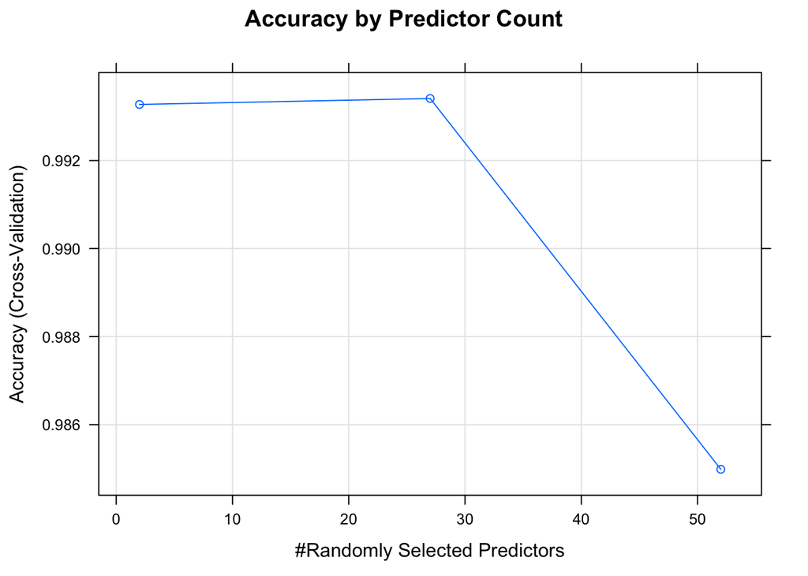

```r
library(doMC)
registerDoMC(cores=3)

set.seed(3825)

control <- trainControl(method="cv", number=10, allowParallel = TRUE)
modRF <- train(classe ~ ., method = "rf", data = dftrn, trControl=control)
plot(modRF,main="Accuracy by Predictor Count")
```

```r
cvconfm <- confusionMatrix.train(modRF)
cvconfm
```

```
## Cross-Validated (10 fold) Confusion Matrix
##
## (entries are percentual average cell counts across resamples)
##
##           Reference
## Prediction    A    B    C    D    E
##          A 28.4  0.1  0.0  0.0  0.0
##          B  0.0 19.2  0.1  0.0  0.0
##          C  0.0  0.1 17.3  0.2  0.0
##          D  0.0  0.0  0.1 16.2  0.1
##          E  0.0  0.0  0.0  0.0 18.3
##
##  Accuracy (average) : 0.9934
```

10-fold cross-validation shows that 27 randomly selected predicors produces the highest accuracy of 0.9934096 with an accuracy SD of 0.001755. The mean estimated out of sample Accuracy is 0.9934094.

```r
confm <- confusionMatrix(dft$classe,predict(modRF,newdata = dft))
```

Using the model to predict test partition shows and Accuracy of 0.9936786 with a confidence interval from 0.9910392 to 0.995701.

```r
confm
```

```
## Confusion Matrix and Statistics
##
##           Reference
## Prediction    A    B    C    D    E
##          A 1394    0    0    0    1
##          B   14  933    1    1    0
##          C    0    1  850    4    0
##          D    0    0    6  797    1
##          E    0    0    2    0  899
##
## Overall Statistics
##
##                Accuracy : 0.9937
##                  95% CI : (0.991, 0.9957)
##     No Information Rate : 0.2871
##     P-Value [Acc > NIR] : < 2.2e-16
##
##                   Kappa : 0.992
##
##  Mcnemar's Test P-Value : NA
##
## Statistics by Class:
##
##                      Class: A Class: B Class: C Class: D Class: E
## Sensitivity            0.9901   0.9989   0.9895   0.9938   0.9978
## Specificity            0.9997   0.9960   0.9988   0.9983   0.9995
## Pos Pred Value         0.9993   0.9831   0.9942   0.9913   0.9978
## Neg Pred Value         0.9960   0.9997   0.9978   0.9988   0.9995
## Prevalence             0.2871   0.1905   0.1752   0.1635   0.1837
## Detection Rate         0.2843   0.1903   0.1733   0.1625   0.1833
## Detection Prevalence   0.2845   0.1935   0.1743   0.1639   0.1837
## Balanced Accuracy      0.9949   0.9974   0.9941   0.9960   0.9986
```

## Quiz

```r
# download and prep quiz data

file <- "pml-testing.csv"
if (!file.exists(file))
  download.file("https://d396qusza40orc.cloudfront.net/predmachlearn/pml-testing.csv",file)
dftesting <- read.csv("pml-testing.csv")
dim(dftesting)
```

```
## [1]  20 160
```

```r
# select only the variables used
dfval <- dftesting[,names(dftrn[,-53])]
dim(dfval)
```

```
## [1] 20 52
```

```r
quiz <- predict(modRF,dfval)
answers <- as.data.frame(quiz)
```

## References

More information is available from the website here: http://web.archive.org/web/20161224072740/http:/groupware.les.inf.puc-rio.br/har (see the section on the Weight Lifting Exercise Dataset).

## Appendix

```r
names(df)
```

```
##   [1] "X"                        "user_name"
##   [3] "raw_timestamp_part_1"     "raw_timestamp_part_2"
##   [5] "cvtd_timestamp"           "new_window"
##   [7] "num_window"               "roll_belt"
##   [9] "pitch_belt"               "yaw_belt"
##  [11] "total_accel_belt"         "kurtosis_roll_belt"
##  [13] "kurtosis_picth_belt"      "kurtosis_yaw_belt"
##  [15] "skewness_roll_belt"       "skewness_roll_belt.1"
##  [17] "skewness_yaw_belt"        "max_roll_belt"
##  [19] "max_picth_belt"           "max_yaw_belt"
##  [21] "min_roll_belt"            "min_pitch_belt"
##  [23] "min_yaw_belt"             "amplitude_roll_belt"
##  [25] "amplitude_pitch_belt"     "amplitude_yaw_belt"
##  [27] "var_total_accel_belt"     "avg_roll_belt"
##  [29] "stddev_roll_belt"         "var_roll_belt"
```

[output cut: 65 more lines]